# Actividad_8

Decisiones Bajo Incertidumbre

Universidad Nacional de Colombia

Facultad de Minas

Semestre 2021-01

- Juan David Rivera Builes
- Sandra Milena Berrio Berrio
- Gustavo Rendón Vélez
- Verónica Yohana Garzón Zuluaga

```python
# Carga de tensorflow
#%reset
import tensorflow as tf
import random as rndm
import numpy as np
import pandas as pd
import matplotlib.pyplot as plt
```

```python
# Lectura del conjunto de datos MNIST:
mnist = tf.keras.datasets.mnist # Crea un alias

(x_train, y_train), (x_test, y_test) = mnist.load_data() # Carga los datos que están en uint8
x_train, x_test = x_train / 255.0, x_test / 255.0 # Vuelve los valores de intensidad números flotantes
```

```
Downloading data from https://storage.googleapis.com/tensorflow/tf-keras-datasets/mnist.npz
```

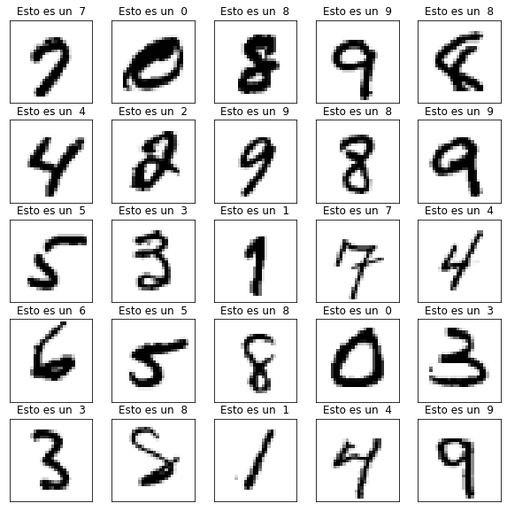

```python
# Ahora veamos la representación de varios dígitos a la vez:
rndm.seed(1)
index = rndm.sample(range(len(y_train)),k=25)
plt.figure(figsize=(10,10))
for i in range(25):
    plt.subplot(5,5,i+1)
    plt.xticks([])
    plt.yticks([])
    plt.grid(False)
    plt.imshow(x_train[index[i]], cmap=plt.cm.binary)
    plt.title(f"Esto es un  {y_train[index[i]]}")
plt.show()
```

```python
from keras import backend as K
from sklearn.metrics import confusion_matrix
from keras.models import Sequential
from keras.losses import SparseCategoricalCrossentropy
from keras.layers import  Flatten, Dense, Dropout, Softmax
from keras.optimizers import SGD, RMSprop, Adagrad, Adadelta

# Esta función define la función de pérdida con la que se entrena el modelo:
loss_fn = SparseCategoricalCrossentropy(from_logits=True)

learning_rate = [0.001, 0.1, 0.5, 0.9, 1.5]
```

```python
def plot_data(model, history):

  y_pred = model(x_train).numpy() # Predicciones en la escala logit
  y_pred = np.argmax(y_pred,axis=1) # Predicciones de los datos.
  cm = confusion_matrix(y_train, y_pred)

  plt.figure(figsize=(10,5))
  plt.subplot(1,2,1)
  plt.title("Loss vs epoch")
  plt.xlabel('Epoch')
  plt.ylabel('Loss')
  plt.grid(True)
  plt.plot(history.history['loss'])

  plt.subplot(1,2,2)
  plt.title("Accuracy vs epoch")
  plt.xlabel('Epoch')
  plt.ylabel('Accuracy')
  plt.grid(True)
  plt.plot(history.history['accuracy'])
  plt.show()

  #print(f"\nMatriz de confusión \n\n {cm}")

  return cm
```

```
Entrenando el modelo con optimizador SGD


Tasa de aprendizaje 0.001

313/313 - 1s - loss: 0.4783 - accuracy: 0.8796

Evaluando conjunto de validacion:

Pérdida conjunto de validacion: 0.47829893231391907
Accuracy conjunto de validacion: 0.8795999884605408
```

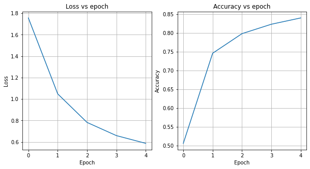

```
Tasa de aprendizaje 0.1

313/313 - 1s - loss: 0.0847 - accuracy: 0.9741

Evaluando conjunto de validacion:

Pérdida conjunto de validacion: 0.08474266529083252
Accuracy conjunto de validacion: 0.9740999937057495
```

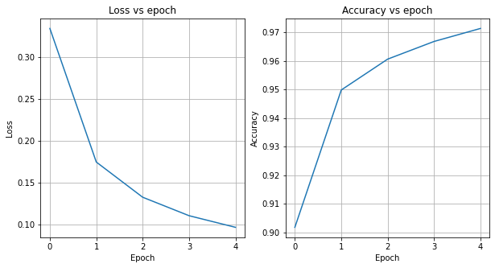

```
Tasa de aprendizaje 0.5

313/313 - 1s - loss: 0.1013 - accuracy: 0.9707

Evaluando conjunto de validacion:

Pérdida conjunto de validacion: 0.10132968425750732
Accuracy conjunto de validacion: 0.9707000255584717
```

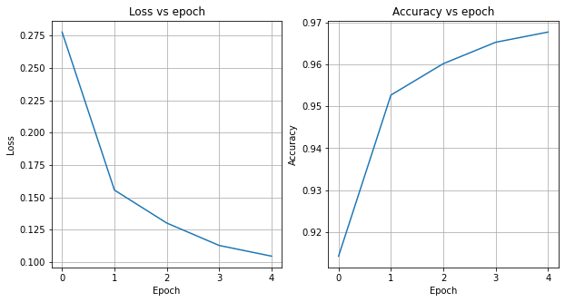

```
Tasa de aprendizaje 0.9

313/313 - 1s - loss: 0.1609 - accuracy: 0.9616

Evaluando conjunto de validacion:

Pérdida conjunto de validacion: 0.1608538031578064
Accuracy conjunto de validacion: 0.9616000056266785
```

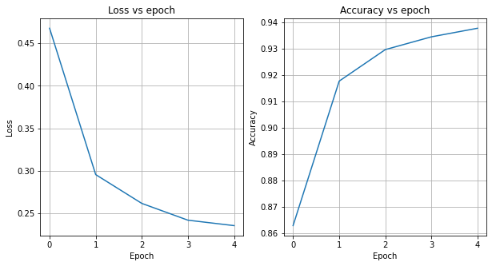

```
Tasa de aprendizaje 1.5

313/313 - 1s - loss: 1.7927 - accuracy: 0.2974

Evaluando conjunto de validacion:

Pérdida conjunto de validacion: 1.792664647102356
Accuracy conjunto de validacion: 0.29739999771118164
```

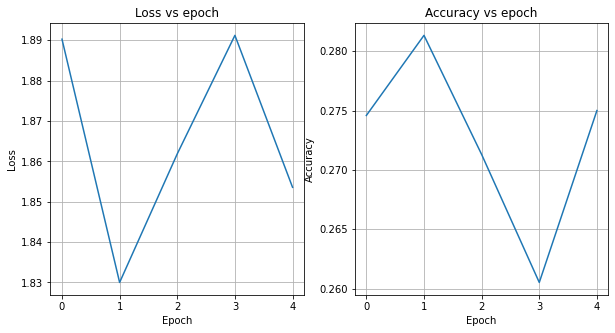

```
Entrenando el modelo con optimizador RMSprop


Tasa de aprendizaje 0.001

313/313 - 1s - loss: 0.1090 - accuracy: 0.9733

Evaluando conjunto de validacion:

Pérdida conjunto de validacion: 0.10899215936660767
Accuracy conjunto de validacion: 0.9732999801635742
```

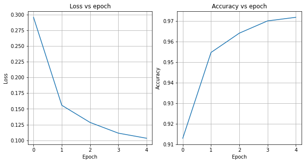

```
Tasa de aprendizaje 0.1

313/313 - 1s - loss: 1.7528 - accuracy: 0.7151

Evaluando conjunto de validacion:

Pérdida conjunto de validacion: 1.7528403997421265
Accuracy conjunto de validacion: 0.7150999903678894
```

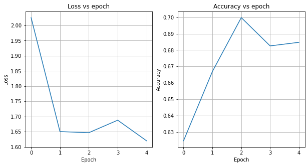

```
Tasa de aprendizaje 0.5

313/313 - 1s - loss: 2.5915 - accuracy: 0.3126

Evaluando conjunto de validacion:

Pérdida conjunto de validacion: 2.591536283493042
Accuracy conjunto de validacion: 0.3125999867916107
```

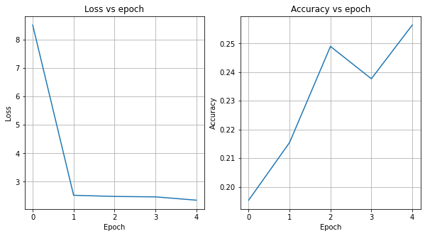

```
Tasa de aprendizaje 0.9

313/313 - 1s - loss: 2.7498 - accuracy: 0.1986

Evaluando conjunto de validacion:

Pérdida conjunto de validacion: 2.74979829788208
Accuracy conjunto de validacion: 0.19859999418258667
```

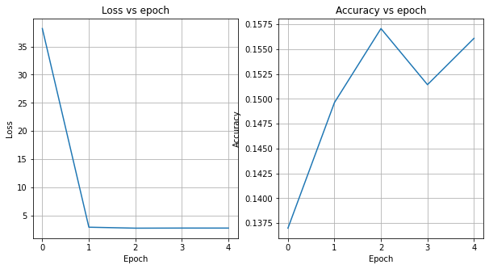

```
Tasa de aprendizaje 1.5

313/313 - 1s - loss: 4.9370 - accuracy: 0.1343

Evaluando conjunto de validacion:

Pérdida conjunto de validacion: 4.937034606933594
Accuracy conjunto de validacion: 0.13429999351501465
```

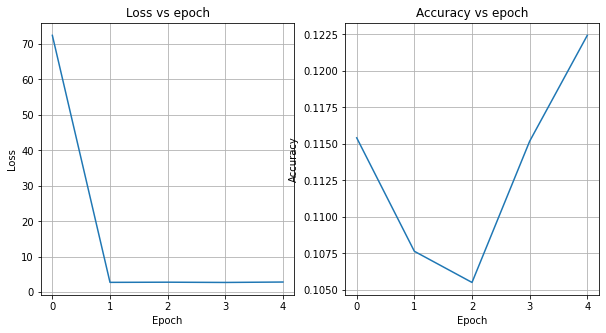

```
Entrenando el modelo con optimizador Adagrad


Tasa de aprendizaje 0.001

313/313 - 1s - loss: 0.3963 - accuracy: 0.8978

Evaluando conjunto de validacion:

Pérdida conjunto de validacion: 0.3962579369544983
Accuracy conjunto de validacion: 0.8978000283241272
```

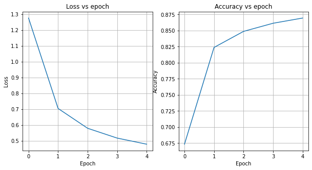

```
Tasa de aprendizaje 0.1

313/313 - 1s - loss: 0.0715 - accuracy: 0.9777

Evaluando conjunto de validacion:

Pérdida conjunto de validacion: 0.07152389734983444
Accuracy conjunto de validacion: 0.9776999950408936
```

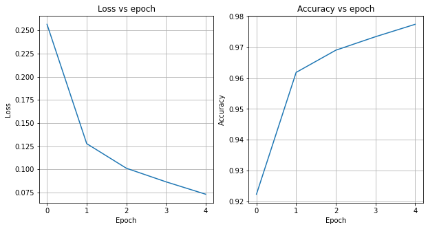

```
Tasa de aprendizaje 0.5

313/313 - 1s - loss: 0.1742 - accuracy: 0.9498

Evaluando conjunto de validacion:

Pérdida conjunto de validacion: 0.17420350015163422
Accuracy conjunto de validacion: 0.9498000144958496
```

[8 more figures not shown]

```python
optim = {
    "SGD":[],
    "RMSprop":[],
    "Adagrad":[],
    "Adadelta":[],
}

for opt in optim:
  print(f"\n\nEntrenando el modelo con optimizador {opt}\n")

  for lr in learning_rate:
    print(f"\nTasa de aprendizaje {lr}\n")

    # Crea el objeto 'model', que es una red secuencial
    model = Sequential()
    # Convierte una matriz en un vector
    model.add(Flatten(input_shape=(28, 28)))
    # Crea una capa de 128 neurones
    model.add(Dense(128, activation='relu'))
    # Define que en cada iteración el 20% de las neuronas no cambian
    model.add(Dropout(0.2))
    # Define 10 neuronas en la capa de salida
    model.add(Dense(10))
    #Compila el modelo con el optimizador y la función de pérdida elegida
    model.compile(optimizer=opt, loss=loss_fn, metrics = ['accuracy'])
    #Asigna al optimizar la tasa de apredizaje
    K.set_value(model.optimizer.lr, lr)

    #Entrenamiento
    history = model.fit(x_train, y_train, epochs=5)

    # Aquí se evalúa el modelo en el conjunto de validación:
    val_metrics = model.evaluate(x_test,  y_test, verbose=2)
    print(f"\nEvaluando conjunto de validacion:")
    print(f"\nPérdida conjunto de validacion: {val_metrics[0]}")
    print(f"Accuracy conjunto de validacion: {val_metrics[1]}\n")

    # Aquí se crea el un nuevo modelo cuya salida es probabilística (entre 0 y 1). Para ello se combina el modelo
    # anterior con un layer softmax al final
    model_p = Sequential([model,Softmax()])

    #Guarda la información del modelo
    optim[opt].append(
        {
          "lr" : lr,
          "model" : model,
          "model_p" : model_p,
          "history" : history,
          "loss" : val_metrics[0],
          "accuracy" : val_metrics[1],
          "cm": pd.DataFrame(plot_data(model, history))
      }
    )
```

## Reduciendo a 600 datos

```
Entrenando el modelo con optimizador SGD


Tasa de aprendizaje 0.001

313/313 - 1s - loss: 2.2139 - accuracy: 0.1968

Evaluando conjunto de validacion:

Pérdida conjunto de validacion: 2.2139077186584473
Accuracy conjunto de validacion: 0.19679999351501465
```

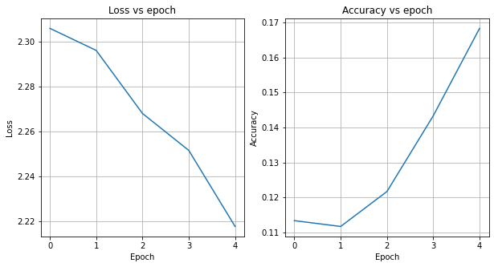

```
Tasa de aprendizaje 0.1

313/313 - 1s - loss: 0.5984 - accuracy: 0.8204

Evaluando conjunto de validacion:

Pérdida conjunto de validacion: 0.5983946323394775
Accuracy conjunto de validacion: 0.8203999996185303
```

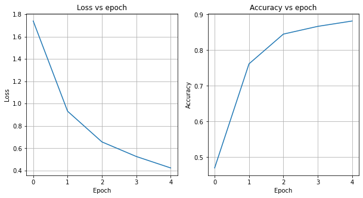

```
Tasa de aprendizaje 0.5

313/313 - 1s - loss: 0.4815 - accuracy: 0.8531

Evaluando conjunto de validacion:

Pérdida conjunto de validacion: 0.4815308451652527
Accuracy conjunto de validacion: 0.8531000018119812
```

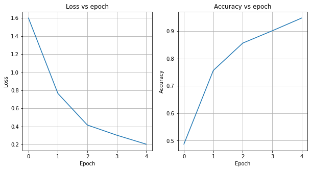

```
Tasa de aprendizaje 0.9

313/313 - 1s - loss: 0.8692 - accuracy: 0.7469

Evaluando conjunto de validacion:

Pérdida conjunto de validacion: 0.8691758513450623
Accuracy conjunto de validacion: 0.7469000220298767
```

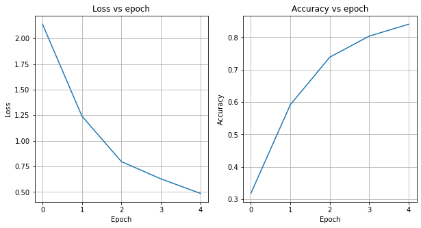

```
Tasa de aprendizaje 1.5

313/313 - 1s - loss: 1.9835 - accuracy: 0.3020

Evaluando conjunto de validacion:

Pérdida conjunto de validacion: 1.9834587574005127
Accuracy conjunto de validacion: 0.3019999861717224
```

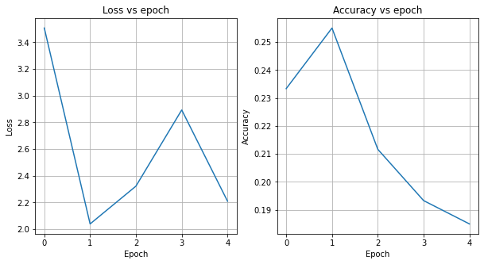

```
Entrenando el modelo con optimizador RMSprop


Tasa de aprendizaje 0.001

313/313 - 1s - loss: 0.5445 - accuracy: 0.8375

Evaluando conjunto de validacion:

Pérdida conjunto de validacion: 0.5444520711898804
Accuracy conjunto de validacion: 0.8374999761581421
```

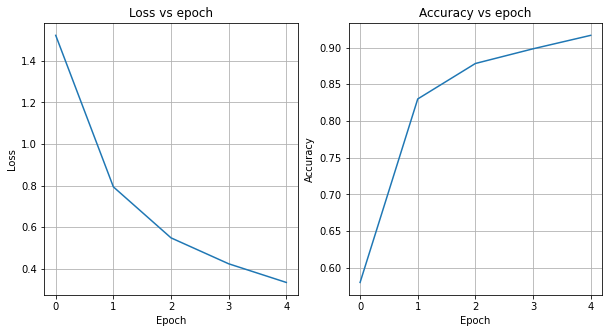

```
Tasa de aprendizaje 0.1

313/313 - 1s - loss: 2.1298 - accuracy: 0.7451

Evaluando conjunto de validacion:

Pérdida conjunto de validacion: 2.1297850608825684
Accuracy conjunto de validacion: 0.7451000213623047
```

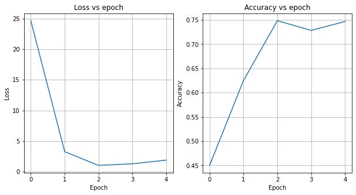

```
Tasa de aprendizaje 0.5

313/313 - 1s - loss: 80.3967 - accuracy: 0.3503

Evaluando conjunto de validacion:

Pérdida conjunto de validacion: 80.39674377441406
Accuracy conjunto de validacion: 0.35030001401901245
```

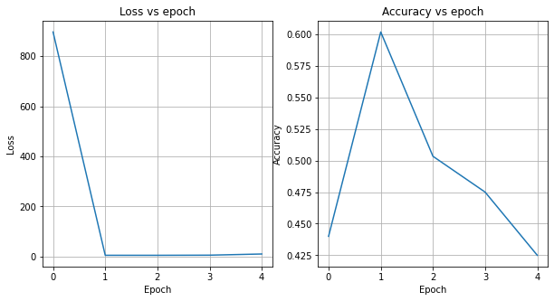

```
Tasa de aprendizaje 0.9

313/313 - 1s - loss: 4.5384 - accuracy: 0.2957

Evaluando conjunto de validacion:

Pérdida conjunto de validacion: 4.538419723510742
Accuracy conjunto de validacion: 0.2957000136375427
```

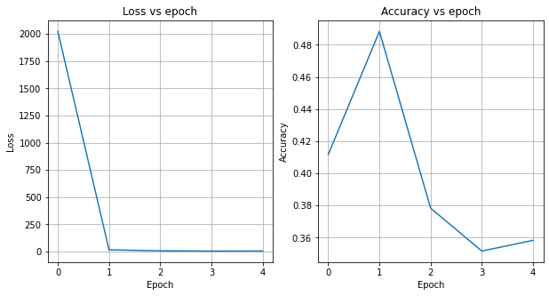

```
Tasa de aprendizaje 1.5

313/313 - 1s - loss: 6.5284 - accuracy: 0.2126

Evaluando conjunto de validacion:

Pérdida conjunto de validacion: 6.528382301330566
Accuracy conjunto de validacion: 0.2125999927520752
```

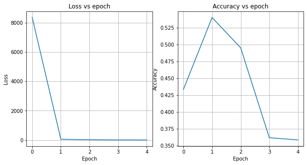

```
Entrenando el modelo con optimizador Adagrad


Tasa de aprendizaje 0.001

313/313 - 1s - loss: 2.0637 - accuracy: 0.3073

Evaluando conjunto de validacion:

Pérdida conjunto de validacion: 2.0637423992156982
Accuracy conjunto de validacion: 0.30730000138282776
```

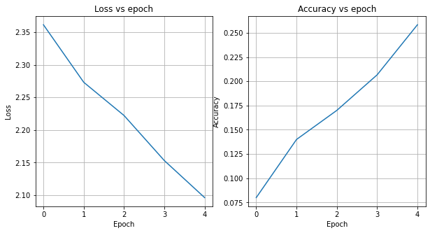

```
Tasa de aprendizaje 0.1

313/313 - 1s - loss: 0.5304 - accuracy: 0.8258

Evaluando conjunto de validacion:

Pérdida conjunto de validacion: 0.5303728580474854
Accuracy conjunto de validacion: 0.8258000016212463
```

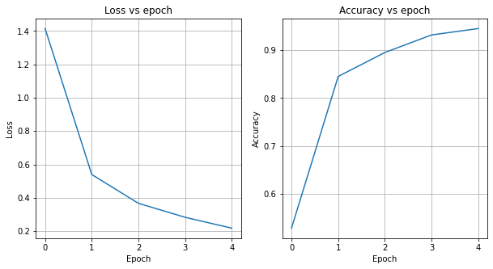

```
Tasa de aprendizaje 0.5

313/313 - 1s - loss: 1.0465 - accuracy: 0.6216

Evaluando conjunto de validacion:

Pérdida conjunto de validacion: 1.0464503765106201
Accuracy conjunto de validacion: 0.6215999722480774
```

[8 more figures not shown]

```python
x_train_600 = x_train[:600,:,:]
y_train_600 = y_train[:600]

optim_600 = {
    "SGD":[],
    "RMSprop":[],
    "Adagrad":[],
    "Adadelta":[],
}

for opt in optim_600:
  print(f"\n\nEntrenando el modelo con optimizador {opt}\n")

  for lr in learning_rate:
    print(f"\nTasa de aprendizaje {lr}\n")

    # Crea el objeto 'model', que es una red secuencial
    model = Sequential()
    # Convierte una matriz en un vector
    model.add(Flatten(input_shape=(28, 28)))
    # Crea una capa de 128 neurones
    model.add(Dense(128, activation='relu'))
    # Define que en cada iteración el 20% de las neuronas no cambian
    model.add(Dropout(0.2))
    # Define 10 neuronas en la capa de salida
    model.add(Dense(10))
    #Compila el modelo con el optimizador y la función de pérdida elegida
    model.compile(optimizer=opt, loss=loss_fn, metrics = ['accuracy'])
    #Asigna al optimizar la tasa de apredizaje
    K.set_value(model.optimizer.lr, lr)

    #Entrenamiento
    history = model.fit(x_train_600, y_train_600, epochs=5)

    # Aquí se evalúa el modelo en el conjunto de validación:
    val_metrics = model.evaluate(x_test,  y_test, verbose=2)
    print(f"\nEvaluando conjunto de validacion:")
    print(f"\nPérdida conjunto de validacion: {val_metrics[0]}")
    print(f"Accuracy conjunto de validacion: {val_metrics[1]}\n")

    # Aquí se crea el un nuevo modelo cuya salida es probabilística (entre 0 y 1). Para ello se combina el modelo
    # anterior con un layer softmax al final
    model_p = Sequential([model,Softmax()])

    #Guarda la información del modelo
    optim_600[opt].append(
        {
          "lr" : lr,
          "model" : model,
          "model_p" : model_p,
          "history" : history,
          "loss" : val_metrics[0],
          "accuracy" : val_metrics[1],
          "cm" : pd.DataFrame(plot_data(model, history))
      }
    )
```

Realizamos las diferencias entre los diferentes métodos y tasas de Aprendizaje, con el fin de observar cuales métodos y tasas tendrian una diferencia mucho más baja.

```python
df_comp = pd.DataFrame(columns=['optimizer', 'lr', 'accuracy_test', 'accuracy_train', 'loss', 'over'])
df_600 = pd.DataFrame(columns=['optimizer', 'lr', 'accuracy_test', 'accuracy_train', 'loss', 'over'])

for o in optim:
  for d in optim[o]:
    new_row = {
        'optimizer':o,
        'lr':d['lr'],
        'accuracy_test':d['accuracy'],
        'accuracy_train': sum(np.diag(d['cm']))/len(y_train),
        'loss':d['loss'],
        'over' : d['accuracy'] < sum(np.diag(d['cm']))/len(y_train)
    }
    df_comp = df_comp.append(new_row, ignore_index=True)

for o in optim_600:
  for d in optim_600[o]:
    new_row = {
        'optimizer':o,
        'lr':d['lr'],
        'accuracy_test':d['accuracy'],
        'accuracy_train': sum(np.diag(d['cm']))/len(y_train),
        'loss':d['loss'],
        'over' : d['accuracy'] < sum(np.diag(d['cm']))/len(y_train)
        }
    df_600 = df_600.append(new_row, ignore_index=True)


df = df_comp.merge(df_600, on=['optimizer', 'lr'], suffixes=('_comp', '_600'))


df['dif_accuracy_test_comp_600'] = df['accuracy_test_comp'] - df['accuracy_test_600']
df['dif_accuracy_train_comp_600'] = df['accuracy_train_comp'] - df['accuracy_train_600']

df
```

|  | optimizer | lr | accuracy_test_comp | accuracy_train_comp | loss_comp | over_comp | accuracy_test_600 | accuracy_train_600 | loss_600 | over_600 | dif_accuracy_test_comp_600 | dif_accuracy_train_comp_600 |
| --- | --- | --- | --- | --- | --- | --- | --- | --- | --- | --- | --- | --- |
| 0 | SGD | 0.001 | 0.8796 | 0.873267 | 0.478299 | False | 0.1968 | 0.184567 | 2.213908 | False | 0.6828 | 0.688700 |
| 1 | SGD | 0.100 | 0.9741 | 0.982950 | 0.084743 | True | 0.8204 | 0.818967 | 0.598395 | False | 0.1537 | 0.163983 |
| 2 | SGD | 0.500 | 0.9707 | 0.981700 | 0.101330 | True | 0.8531 | 0.852000 | 0.481531 | False | 0.1176 | 0.129700 |
| 3 | SGD | 0.900 | 0.9616 | 0.968633 | 0.160854 | True | 0.7469 | 0.746983 | 0.869176 | True | 0.2147 | 0.221650 |
| 4 | SGD | 1.500 | 0.2974 | 0.294467 | 1.792665 | False | 0.3020 | 0.296700 | 1.983459 | False | -0.0046 | -0.002233 |
| 5 | RMSprop | 0.001 | 0.9733 | 0.982033 | 0.108992 | True | 0.8375 | 0.835600 | 0.544452 | False | 0.1358 | 0.146433 |
| 6 | RMSprop | 0.100 | 0.7151 | 0.718567 | 1.752840 | True | 0.7451 | 0.752400 | 2.129785 | True | -0.0300 | -0.033833 |
| 7 | RMSprop | 0.500 | 0.3126 | 0.315400 | 2.591536 | True | 0.3503 | 0.342300 | 80.396744 | False | -0.0377 | -0.026900 |
| 8 | RMSprop | 0.900 | 0.1986 | 0.188650 | 2.749798 | False | 0.2957 | 0.295050 | 4.538420 | False | -0.0971 | -0.106400 |
| 9 | RMSprop | 1.500 | 0.1343 | 0.133050 | 4.937035 | False | 0.2126 | 0.223183 | 6.528382 | True | -0.0783 | -0.090133 |
| 10 | Adagrad | 0.001 | 0.8978 | 0.894067 | 0.396258 | False | 0.3073 | 0.304633 | 2.063742 | False | 0.5905 | 0.589433 |
| 11 | Adagrad | 0.100 | 0.9777 | 0.988233 | 0.071524 | True | 0.8258 | 0.823367 | 0.530373 | False | 0.1519 | 0.164867 |
| 12 | Adagrad | 0.500 | 0.9498 | 0.952533 | 0.174204 | True | 0.6216 | 0.625700 | 1.046450 | True | 0.3282 | 0.326833 |
| 13 | Adagrad | 0.900 | 0.4751 | 0.479650 | 1.371372 | True | 0.1032 | 0.099250 | 2.303868 | False | 0.3719 | 0.380400 |
| 14 | Adagrad | 1.500 | 0.1135 | 0.112367 | 2.301832 | False | 0.1096 | 0.108833 | 2.307237 | False | 0.0039 | 0.003533 |
| 15 | Adadelta | 0.001 | 0.5974 | 0.592150 | 1.729934 | False | 0.1112 | 0.112683 | 2.385956 | True | 0.4862 | 0.479467 |
| 16 | Adadelta | 0.100 | 0.9436 | 0.942450 | 0.198461 | False | 0.6253 | 0.626033 | 1.579248 | True | 0.3183 | 0.316417 |
| 17 | Adadelta | 0.500 | 0.9701 | 0.974433 | 0.104850 | True | 0.7980 | 0.790367 | 0.702214 | False | 0.1721 | 0.184067 |
| 18 | Adadelta | 0.900 | 0.9745 | 0.980683 | 0.086086 | True | 0.8348 | 0.829717 | 0.551241 | False | 0.1397 | 0.150967 |
| 19 | Adadelta | 1.500 | 0.9757 | 0.984267 | 0.081531 | True | 0.8390 | 0.833500 | 0.528400 | False | 0.1367 | 0.150767 |

Para valores más positivos de estas diferencias sumadas concluiriamos entonces que los métodos con los datos completos fuerón buenos y se afectarón realmente con la reducción de datos, lo opuesto sucede con los valores negativos, dando indicios de que la reducción fue mejor para el método.

```python
df2 = df.sort_values(by=['optimizer', 'dif_accuracy_test_comp_600', 'dif_accuracy_train_comp_600'], ascending=False)
df3 = df2[['optimizer', 'lr', 'dif_accuracy_test_comp_600', 'dif_accuracy_train_comp_600']]

df3.groupby(['optimizer']).agg({'dif_accuracy_test_comp_600' : ['sum'], 'dif_accuracy_train_comp_600' : ['sum']})
```

| optimizer | dif_accuracy_test_comp_600 sum | dif_accuracy_train_comp_600 sum |
| --- | --- | --- |
| Adadelta | 1.2530 | 1.281683 |
| Adagrad | 1.4464 | 1.465067 |
| RMSprop | -0.1073 | -0.110833 |
| SGD | 1.1642 | 1.201800 |

Se observa entonces que el método RMSProp fue el menos afectado de echo, tuvoun mejor desempeño global con la reducción de los datos.

```python
df2 = df.sort_values(by=['lr', 'dif_accuracy_test_comp_600', 'dif_accuracy_train_comp_600'], ascending=False)
df3 = df2[['lr', 'optimizer', 'dif_accuracy_test_comp_600', 'dif_accuracy_train_comp_600']]

df3.groupby(['lr']).agg({'dif_accuracy_test_comp_600' : ['sum'], 'dif_accuracy_train_comp_600' : ['sum']})
```

| lr | dif_accuracy_test_comp_600 sum | dif_accuracy_train_comp_600 sum |
| --- | --- | --- |
| 0.001 | 1.8953 | 1.904033 |
| 0.100 | 0.5939 | 0.611433 |
| 0.500 | 0.5802 | 0.613700 |
| 0.900 | 0.6292 | 0.646617 |
| 1.500 | 0.0577 | 0.061933 |

El mismo análisis aplica para la tasa de aprendizaje siendo la 1.5 con menor diferencia en reducción de datos.

[output not shown]

# Actividad 08: optimización y redes neuronales

El objetivo de esta actividad es afianzar los conocimientos de optimización numérica y su importancia en el entrenamiento de modelos de aprendizaje de máquina.

Para ello se considera el tutorial de reconocimiento de dígitos con el conjunto de datos MNIST de la Guia inicial de TensorFlow 2.0 para principiantes.

El conjunto de entrenamiento contiene 60,000 imágenes de entrenamiento y 10,000 imágenes de validación.

### Actividades

Reproduzca el tutorial citado completándolo con la fórmula matemática de la función de pérdida.

El entrenamiento con un alto volúmen de imágenes tiene a producir buenos resultados independiente del optimizador. Cambie el método de optimización por SGD RSMprop Adagram Adadelta

En cada caso varíe la tasa de aprendizaje η=0.001,0.1,0.5,0.9,1.5

manteniendo los otros parámetros del optimizador en sus valores por defecto. Reporte el accuracy en el conjunto de datos en entrenamiento y validaciónn (los 10,000 datos). Reporte las gráficas de la función de pérdida y del accuracy durante el proceso de optimización.

1. ¿Cuál fue el método de optimización menos afectado por la reducción del conjunto de datos?
   - El méétodo de optimización menos afectado fue RMSprop
1. ¿Cuál fue la tasa de aprendizaje menos afectada por la reducción del conjunto de datos?
   - La tasa de aprendizaje que menos se vió afectada es la 1.5
2. ¿Cuál fue el método que más rápido convergió?

## Fuentes Utilizadas:

Team, K. (s. f.-a). Keras documentation: Losses. Keras API Reference. Recuperado 30 de julio de 2021, de https://keras.io/api/losses/

Team, K. (s. f.-b). Keras documentation: Optimizers. Keras API Reference. Recuperado 30 de julio de 2021, de https://keras.io/api/optimizers/

Team, K. (s. f.-c). Keras documentation: metrics. Keras API Reference. Recuperado 30 de julio de 2021, de https://keras.io/api/metrics/